# titanic

Opis kolumny:

- **pclass** - Klasa biletu
- **survived** - Czy pasażer przeżył katastrofę
- **name** - Imię i nazwisko pasażera
- **sex** - Płeć pasażera
- **age** - Wiek pasażera
- **sibsp** - Liczba rodzeństwa/małżonków na pokładzie
- **parch** - Liczba rodziców/dzieci na pokładzie
- **ticket** - Numer biletu
- **fare** - Cena biletu
- **cabin** - Numer kabiny
- **embarked** - Port, w którym pasażer wszedł na pokład (C = Cherbourg, Q = Queenstown, S = Southampton)
- **boat** - Numer łodzi ratunkowej
- **body** - Numer ciała (jeśli pasażer nie przeżył i ciało zostało odnalezione)
- **home.dest** - Miejsce docelowe

# Titanic

```python
# Importowanie bibliotek
import pandas as pd
import matplotlib.pyplot as pl
import seaborn as sns
import plotly.express as px
```

```python
df = pd.read_csv('26__titanic.csv', sep=",")
df
```

|  | pclass | survived | name | sex | age | sibsp | parch | ticket | fare | cabin | embarked | boat | body | home.dest |
| --- | --- | --- | --- | --- | --- | --- | --- | --- | --- | --- | --- | --- | --- | --- |
| 0 | 1.0 | 1.0 | Allen, Miss. Elisabeth Walton | female | 29.0000 | 0.0 | 0.0 | 24160 | 211.3375 | B5 | S | 2 | NaN | St Louis, MO |
| 1 | 1.0 | 1.0 | Allison, Master. Hudson Trevor | male | 0.9167 | 1.0 | 2.0 | 113781 | 151.5500 | C22 C26 | S | 11 | NaN | Montreal, PQ / Chesterville, ON |
| 2 | 1.0 | 0.0 | Allison, Miss. Helen Loraine | female | 2.0000 | 1.0 | 2.0 | 113781 | 151.5500 | C22 C26 | S | NaN | NaN | Montreal, PQ / Chesterville, ON |
| 3 | 1.0 | 0.0 | Allison, Mr. Hudson Joshua Creighton | male | 30.0000 | 1.0 | 2.0 | 113781 | 151.5500 | C22 C26 | S | NaN | 135.0 | Montreal, PQ / Chesterville, ON |
| 4 | 1.0 | 0.0 | Allison, Mrs. Hudson J C (Bessie Waldo Daniels) | female | 25.0000 | 1.0 | 2.0 | 113781 | 151.5500 | C22 C26 | S | NaN | NaN | Montreal, PQ / Chesterville, ON |
| ... | ... | ... | ... | ... | ... | ... | ... | ... | ... | ... | ... | ... | ... | ... |
| 1305 | 3.0 | 0.0 | Zabour, Miss. Thamine | female | NaN | 1.0 | 0.0 | 2665 | 14.4542 | NaN | C | NaN | NaN | NaN |
| 1306 | 3.0 | 0.0 | Zakarian, Mr. Mapriededer | male | 26.5000 | 0.0 | 0.0 | 2656 | 7.2250 | NaN | C | NaN | 304.0 | NaN |
| 1307 | 3.0 | 0.0 | Zakarian, Mr. Ortin | male | 27.0000 | 0.0 | 0.0 | 2670 | 7.2250 | NaN | C | NaN | NaN | NaN |
| 1308 | 3.0 | 0.0 | Zimmerman, Mr. Leo | male | 29.0000 | 0.0 | 0.0 | 315082 | 7.8750 | NaN | S | NaN | NaN | NaN |
| 1309 | NaN | NaN | NaN | NaN | NaN | NaN | NaN | NaN | NaN | NaN | NaN | NaN | NaN | NaN |

1310 rows × 14 columns

# 1. Zrozumienie danych

```python
df.shape[0] #ilość rekordów w bazie
```

```
1310
```

```python
df.index
```

```
RangeIndex(start=0, stop=1310, step=1)
```

```python
df.info()
```

```
<class 'pandas.core.frame.DataFrame'>
RangeIndex: 1310 entries, 0 to 1309
Data columns (total 14 columns):
 #   Column     Non-Null Count  Dtype
---  ------     --------------  -----
 0   pclass     1309 non-null   float64
 1   survived   1309 non-null   float64
 2   name       1309 non-null   object
 3   sex        1309 non-null   object
 4   age        1046 non-null   float64
 5   sibsp      1309 non-null   float64
 6   parch      1309 non-null   float64
 7   ticket     1309 non-null   object
 8   fare       1308 non-null   float64
 9   cabin      295 non-null    object
 10  embarked   1307 non-null   object
 11  boat       486 non-null    object
 12  body       121 non-null    float64
 13  home.dest  745 non-null    object
dtypes: float64(7), object(7)
memory usage: 143.4+ KB
```

```python
df.describe() # Wyświetlenie danych statystycznych
```

|  | pclass | survived | age | sibsp | parch | fare | body |
| --- | --- | --- | --- | --- | --- | --- | --- |
| count | 1309.000000 | 1309.000000 | 1046.000000 | 1309.000000 | 1309.000000 | 1308.000000 | 121.000000 |
| mean | 2.294882 | 0.381971 | 29.881135 | 0.498854 | 0.385027 | 33.295479 | 160.809917 |
| std | 0.837836 | 0.486055 | 14.413500 | 1.041658 | 0.865560 | 51.758668 | 97.696922 |
| min | 1.000000 | 0.000000 | 0.166700 | 0.000000 | 0.000000 | 0.000000 | 1.000000 |
| 25% | 2.000000 | 0.000000 | 21.000000 | 0.000000 | 0.000000 | 7.895800 | 72.000000 |
| 50% | 3.000000 | 0.000000 | 28.000000 | 0.000000 | 0.000000 | 14.454200 | 155.000000 |
| 75% | 3.000000 | 1.000000 | 39.000000 | 1.000000 | 0.000000 | 31.275000 | 256.000000 |
| max | 3.000000 | 1.000000 | 80.000000 | 8.000000 | 9.000000 | 512.329200 | 328.000000 |

```python
df.sample(10) # Wyświetlenie 10 przykładowych wierszy
```

|  | pclass | survived | name | sex | age | sibsp | parch | ticket | fare | cabin | embarked | boat | body | home.dest |
| --- | --- | --- | --- | --- | --- | --- | --- | --- | --- | --- | --- | --- | --- | --- |
| 753 | 3.0 | 0.0 | Davies, Mr. Evan | male | 22.0 | 0.0 | 0.0 | SC/A4 23568 | 8.0500 | NaN | S | NaN | NaN | NaN |
| 185 | 1.0 | 0.0 | Lindeberg-Lind, Mr. Erik Gustaf ("Mr Edward Li... | male | 42.0 | 0.0 | 0.0 | 17475 | 26.5500 | NaN | S | NaN | NaN | Stockholm, Sweden |
| 286 | 1.0 | 0.0 | Straus, Mrs. Isidor (Rosalie Ida Blun) | female | 63.0 | 1.0 | 0.0 | PC 17483 | 221.7792 | C55 C57 | S | NaN | NaN | New York, NY |
| 137 | 1.0 | 1.0 | Graham, Miss. Margaret Edith | female | 19.0 | 0.0 | 0.0 | 112053 | 30.0000 | B42 | S | 3 | NaN | Greenwich, CT |
| 75 | 1.0 | 0.0 | Colley, Mr. Edward Pomeroy | male | 47.0 | 0.0 | 0.0 | 5727 | 25.5875 | E58 | S | NaN | NaN | Victoria, BC |
| 880 | 3.0 | 1.0 | Jalsevac, Mr. Ivan | male | 29.0 | 0.0 | 0.0 | 349240 | 7.8958 | NaN | C | 15 | NaN | NaN |
| 600 | 3.0 | 0.0 | Abbing, Mr. Anthony | male | 42.0 | 0.0 | 0.0 | C.A. 5547 | 7.5500 | NaN | S | NaN | NaN | NaN |
| 1127 | 3.0 | 0.0 | Petroff, Mr. Nedelio | male | 19.0 | 0.0 | 0.0 | 349212 | 7.8958 | NaN | S | NaN | NaN | NaN |
| 989 | 3.0 | 0.0 | Maisner, Mr. Simon | male | NaN | 0.0 | 0.0 | A/S 2816 | 8.0500 | NaN | S | NaN | NaN | NaN |
| 300 | 1.0 | 0.0 | Van der hoef, Mr. Wyckoff | male | 61.0 | 0.0 | 0.0 | 111240 | 33.5000 | B19 | S | NaN | 245.0 | Brooklyn, NY |

```python
df.nunique() # Wartości ukinatowe
```

```
pclass          3
survived        2
name         1307
sex             2
age            98
sibsp           7
parch           8
ticket        929
fare          281
cabin         186
embarked        3
boat           27
body          121
home.dest     369
dtype: int64
```

### W bazie występuje 1310 rekordów w czternastu kolumnach. Jest to lista pasażerów statku Titanic

# 2. Zrozumienie brakujących wartości w danych

```python
df.isnull().sum() # Czy wysępują braki w danych - podsumowanie
```

```
pclass          1
survived        1
name            1
sex             1
age           264
sibsp           1
parch           1
ticket          1
fare            2
cabin        1015
embarked        3
boat          824
body         1189
home.dest     565
dtype: int64
```

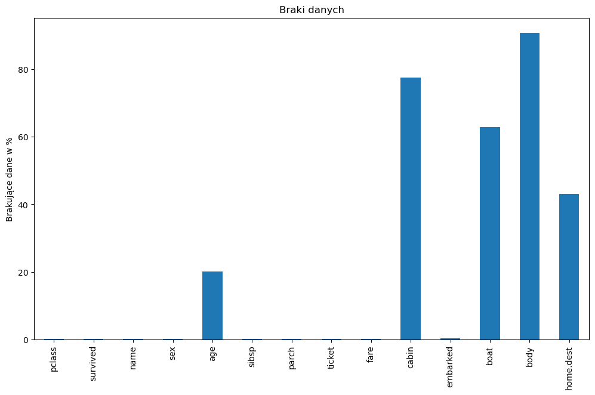

```python
import matplotlib.pyplot as plt

# Calculate percentage of missing data in each column
missing_data = df.isnull().sum() / len(df) * 100

# Plot missing data
missing_data.plot(kind='bar', figsize=(12, 7))
plt.title('Braki danych')
plt.ylabel('Brakujące dane w %')
plt.show()
```

### Analiza dostępnych danych wskazuje na istotne braki w kilku kolumnach, takich jak wiek (264 braków), numer kabiny (1015), numer łodzi ratunkowej (824), numer ciała (1189) czy miejsce docelowe (565). Procentowo największy odsetek braków dotyczy numeru ciała (około 90%), numeru kabiny (około 80%) oraz numeru łodzi ratunkowej (około 60%).

### Wnioski z tej analizy sugerują, że ubytki nie wynikają wyłącznie z błędów wprowadzania danych, ale mogą odzwierciedlać realia katastrofy. Przykładowo, brak numeru ciała może oznaczać, że pasażera nie odnaleziono, natomiast brak numeru łodzi ratunkowej może wskazywać, że dana osoba nie została ewakuowana. Taki rozkład braków jest zatem prawdopodobnie związany z prawdziwymi wydarzeniami na pokładzie Titanica, a nie wyłącznie z niepełną dokumentacją.

```python
df.duplicated().sum() # Suma duplikatów dancych
```

```
0
```

### Nie stwierdzono duplikatów danych

```python
df.loc[1309] # Wiersz bez banych
```

```
pclass       NaN
survived     NaN
name         NaN
sex          NaN
age          NaN
sibsp        NaN
parch        NaN
ticket       NaN
fare         NaN
cabin        NaN
embarked     NaN
boat         NaN
body         NaN
home.dest    NaN
Name: 1309, dtype: object
```

```python
df = df.drop(1309) # Usunięcie pustego wiersza
```

### Ostani wiersz w DF został usuniety z powody braku danych, zakładm, że był to błędny wpis w bazie

# 3. Zrozumienie pojedyńczych zmiennych

```
array([[<Axes: title={'center': 'age'}>,
        <Axes: title={'center': 'pclass'}>],
       [<Axes: title={'center': 'survived'}>,
        <Axes: title={'center': 'age'}>]], dtype=object)
```

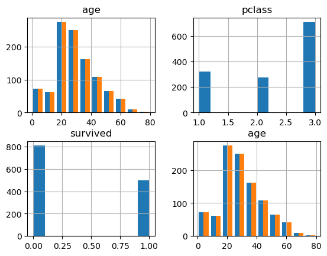

```python
df.hist(["age", "pclass", "survived", "age"])
```

```
array([[<Axes: title={'center': 'sibsp'}>,
        <Axes: title={'center': 'fare'}>]], dtype=object)
```

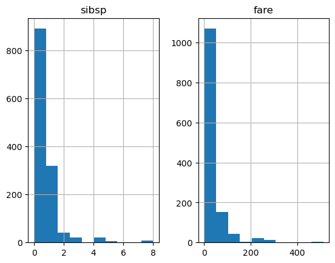

```python
df.hist(["sibsp", "fare"])
```

```python
df["pclass"].value_counts() # klasa biletu
```

```
3.0    709
1.0    323
2.0    277
Name: pclass, dtype: int64
```

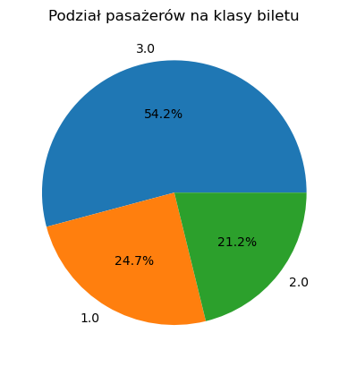

```python
# Rysowanie wykresu Podział pasażerów na klasy biletu
df['pclass'].value_counts().plot(kind='pie', autopct='%1.1f%%')

plt.title('Podział pasażerów na klasy biletu')
plt.ylabel('')  #
plt.show()
```

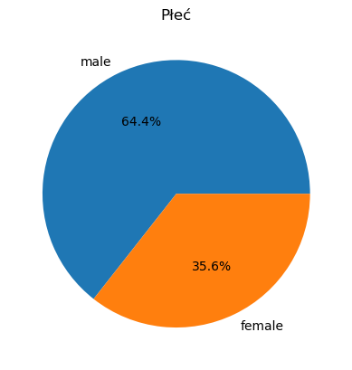

```python
# Rysowanie wykresu - podział na płeć
classes = df["sex"].value_counts()

plt.pie(classes, labels = classes.index, autopct='%1.1f%%')
plt.title('Płeć')
plt.show()
```

### Możemy zauważyć, że pasażerowie 3 klasy stanowili największą grupę, stanowiąc 54,2% wszystkich podróżnych.

### Przeważającą cześć pasażerów bo 64,4 % stanowili meżczyźni

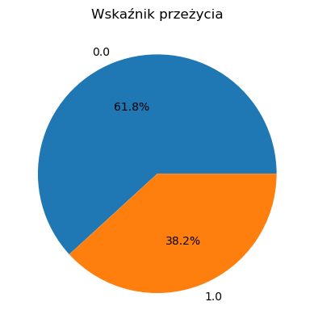

```python
classes = df["survived"].value_counts() # Wskaźnik przeżycia na wykresie kołowym

plt.pie(classes, labels = classes.index, autopct='%1.1f%%')
plt.title('Wskaźnik przeżycia')
plt.show()
```

```python
# Liczba osób która przeżyła
survived_count = df['survived'].sum()

# Output the result
print("Liczba osób, które przeżyły:", survived_count)
```

```
Liczba osób, które przeżyły: 500.0
```

```python
# Odnalezione ciała
non_nan_count = df['body'].notna().sum()

# Output the result
print("Liczba wartości, które nie są NaN w kolumnie 'body':", non_nan_count)
```

```
Liczba wartości, które nie są NaN w kolumnie 'body': 121
```

```python
# Liczba ciał, które nie zostały odnalezione (po odjęciu osób, które przeżyły)
not_found_bodies_count = df['body'].isna().sum()

# Counting the number of people who survived (survived == 1)
survived_count = df['survived'].sum()

# Calculating the number of bodies not found excluding those who survived
bodies_not_found_excluding_survivors = not_found_bodies_count - survived_count

# Output the result
print("Liczba ciał, które nie zostały odnalezione (po odjęciu osób, które przeżyły):", bodies_not_found_excluding_survivors)
```

```
Liczba ciał, które nie zostały odnalezione (po odjęciu osób, które przeżyły): 688.0
```

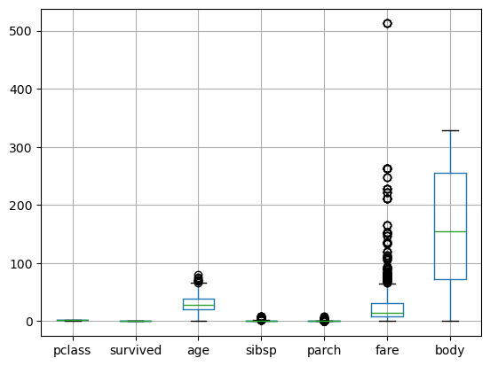

```python
df.boxplot()
```

# 4. Transormacja danych

```python
df2 = df.copy() # Utworzenie df2 na potrzeby transformacji dnaych
```

```python
df2.sample()
```

|  | pclass | survived | name | sex | age | sibsp | parch | ticket | fare | cabin | embarked | boat | body | home.dest |
| --- | --- | --- | --- | --- | --- | --- | --- | --- | --- | --- | --- | --- | --- | --- |
| 1156 | 3.0 | 0.0 | Rosblom, Miss. Salli Helena | female | 2.0 | 1.0 | 1.0 | 370129 | 20.2125 | NaN | S | NaN | NaN | NaN |

```python
# Zmiana wszystkich wartości w kolumnie 'survived' na liczby całkowite
df2['survived'] = df2['survived'].astype(int)
```

```python
df2.info()
```

```
<class 'pandas.core.frame.DataFrame'>
RangeIndex: 1309 entries, 0 to 1308
Data columns (total 14 columns):
 #   Column     Non-Null Count  Dtype
---  ------     --------------  -----
 0   pclass     1309 non-null   float64
 1   survived   1309 non-null   int64
 2   name       1309 non-null   object
 3   sex        1309 non-null   object
 4   age        1046 non-null   float64
 5   sibsp      1309 non-null   float64
 6   parch      1309 non-null   float64
 7   ticket     1309 non-null   object
 8   fare       1308 non-null   float64
 9   cabin      295 non-null    object
 10  embarked   1307 non-null   object
 11  boat       486 non-null    object
 12  body       121 non-null    float64
 13  home.dest  745 non-null    object
dtypes: float64(6), int64(1), object(7)
memory usage: 143.3+ KB
```

```python
# Zmieniam wartości w kolumnie "pclass"
df2["pclass"] = df2["pclass"].replace({1.0: "I klasa",
                                       2.0: "II klasa",
                                       3.0: "III klasa"})
```

```python
df2.sample(3)
```

|  | pclass | survived | name | sex | age | sibsp | parch | ticket | fare | cabin | embarked | boat | body | home.dest |
| --- | --- | --- | --- | --- | --- | --- | --- | --- | --- | --- | --- | --- | --- | --- |
| 795 | III klasa | 0 | Emir, Mr. Farred Chehab | male | NaN | 0.0 | 0.0 | 2631 | 7.2250 | NaN | C | NaN | NaN | NaN |
| 358 | II klasa | 1 | Bystrom, Mrs. (Karolina) | female | 42.0 | 0.0 | 0.0 | 236852 | 13.0000 | NaN | S | NaN | NaN | New York, NY |
| 105 | I klasa | 0 | Evans, Miss. Edith Corse | female | 36.0 | 0.0 | 0.0 | PC 17531 | 31.6792 | A29 | C | NaN | NaN | New York, NY |

```python
# Wyświetlenie ilosci braków w kolumnie 'age'
print(df2['age'].isnull().sum())
```

```
263
```

```python
# Wypełnienie brakujących danych w "age' średnią wieku
df2["age"] = df2["age"].fillna(df2["age"].mean())
```

```python
# Wyświetlenie ilosci braków w kolumnie 'age' po wypełnieniu średnią
print(df2['age'].isnull().sum())
```

```
0
```

```python
df.isnull().sum() # weryfikacja pustych danych po wypełnieniu srednią wieku
```

```
pclass          0
survived        0
name            0
sex             0
age           263
sibsp           0
parch           0
ticket          0
fare            1
cabin        1014
embarked        2
boat          823
body         1188
home.dest     564
dtype: int64
```

### Dla kolumny "survived" zmieniony został typ liczb z float na int. Zostały zmienione opisy klas biletu oraz uzupełniono braki danych wieku pasażerów średnią wartością wieku. Pozstałe barki w danych np. "numer kabiny" czy "numer ciała", zakładamy, że nie będą potrzebne w naszej analizie.

# 5. Zrozumienie relacji miedzy zmiennymi

```python
df2.corr(numeric_only=True)
```

|  | survived | age | sibsp | parch | fare | body |
| --- | --- | --- | --- | --- | --- | --- |
| survived | 1.000000 | -0.050199 | -0.027825 | 0.082660 | 0.244265 | NaN |
| age | -0.050199 | 1.000000 | -0.190747 | -0.130872 | 0.171892 | 0.059059 |
| sibsp | -0.027825 | -0.190747 | 1.000000 | 0.373587 | 0.160238 | -0.099961 |
| parch | 0.082660 | -0.130872 | 0.373587 | 1.000000 | 0.221539 | 0.051099 |
| fare | 0.244265 | 0.171892 | 0.160238 | 0.221539 | 1.000000 | -0.043110 |
| body | NaN | 0.059059 | -0.099961 | 0.051099 | -0.043110 | 1.000000 |

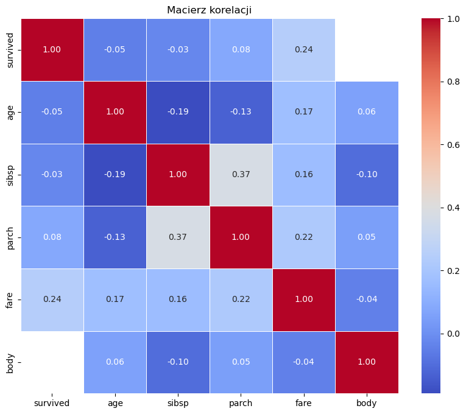

```python
# Obliczanie korelacji tylko dla kolumn numerycznych
correlation_matrix = df2.select_dtypes(include=['number']).corr()

# Rysowanie heatmapy korelacji
#import seaborn as sns
##import matplotlib.pyplot as plt

plt.figure(figsize=(10, 8))
sns.heatmap(correlation_matrix, annot=True, cmap='coolwarm', fmt=".2f", linewidths=0.5)
plt.title('Macierz korelacji')
plt.show()
```

# Analiza macierzy korelacji

## Macierz korelacji przedstawia zależności między różnymi zmiennymi dotyczącymi pasażerów Titanica. Wartości korelacji są przedstawione w skali od -1 (silna korelacja ujemna) do 1 (silna korelacja dodatnia). Im bliżej 0, tym słabsza zależność między zmiennymi.

## Kluczowe obserwacje:

## Przeżycie (survived) a inne zmienne:

- "Fare" (opłata za bilet) ma korelację 0.24 z przeżyciem. To oznacza, że pasażerowie, którzy zapłacili więcej, mieli większe szanse na przeżycie (co może wskazywać na przewagę pasażerów pierwszej klasy).
- "Parch" (liczba członków rodziny na pokładzie) ma korelację 0.08 – bardzo słaba zależność, ale sugeruje, że podróżowanie z rodziną mogło mieć niewielki wpływ na przeżycie.
- "SibSp" (liczba rodzeństwa/małżonków na pokładzie) i "Age" mają korelacje bliskie zeru (-0.03 i -0.05) – oznacza to, że te cechy nie miały istotnego wpływu na przeżycie.

## Wnioski: Najsilniejsza korelacja z przeżyciem występuje dla opłaty za bilet (Fare = 0.24), co potwierdza, że bogatsi pasażerowie mieli większe szanse na przeżycie.

## Czy wiek miał wpływ na przeżycie?

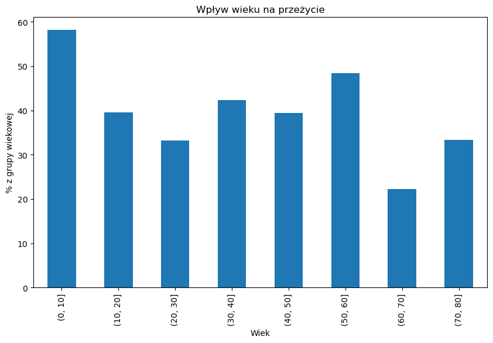

```python
# Import required libraries
import pandas as pd
import matplotlib.pyplot as plt

# Create age groups
age_bins = [0, 10, 20, 30, 40, 50, 60, 70, 80]
df2['age_group'] = pd.cut(df2['age'], bins=age_bins)

# Calculate percentage of survivors in each age group
survival_rate = df2.groupby('age_group')['survived'].mean() * 100

# Generate the bar plot
survival_rate.plot(kind='bar', figsize=(10, 6))

plt.title('Wpływ wieku na przeżycie') # Dodajemy tytuł wykresu
plt.xlabel('Wiek') # Oznaczamy oś X
plt.ylabel('% z grupy wiekowej') # Oznaczamy oś Y


plt.show()
```

### Największe szanse na przeżycie miały dzieci w wieku 0-10 lat (prawie 60%). Może to wynikać z zasady „kobiety i dzieci najpierw” stosowanej podczas ewakuacji.

### Niższa przeżywalność wśród dorosłych – Wiekowe grupy 10-20, 20-30, 30-40, 40-50 lat mają zbliżoną przeżywalność (około 35-45%), co sugeruje brak wyraźnej różnicy w traktowaniu młodych i średnio-wiekowych dorosłych.

### Podwyższona przeżywalność w wieku 50-60 lat – Można zauważyć wzrost przeżywalności w tej grupie (prawie 50%), co może sugerować, że starsi pasażerowie mogli być bardziej uprzywilejowani podczas ewakuacji.

### Najniższa przeżywalność wśród seniorów (60-70 lat) – W tej grupie współczynnik przeżycia jest najniższy (około 20%), co może sugerować trudności w ewakuacji starszych pasażerów.

### Lekki wzrost w grupie 70-80 lat (ok. 30%) może wynikać z małej liczby pasażerów w tym przedziale wiekowym.

## Wykres potwierdza, że dzieci miały największe szanse na przeżycie, a przeżywalność dorosłych była relatywnie wyrównana, z wyjątkiem seniorów, którzy mieli najmniejsze szanse na przeżycie.

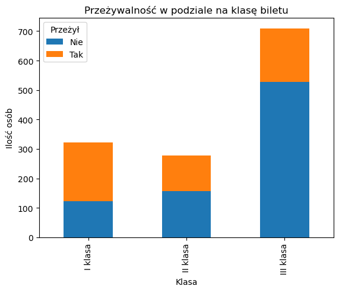

```python
# Grouping the data by 'pclass' and 'survived'
grouped_df2 = df2.groupby(['pclass', 'survived']).size().unstack()

# Plotting the bar chart
grouped_df2.plot(kind='bar', stacked=True)

plt.title('Przeżywalność w podziale na klasę biletu')
plt.xlabel('Klasa')
plt.ylabel('Ilość osób')

plt.legend(['Nie', 'Tak'], title="Przeżył") # Dodanie legendy
# Displaying the plot
plt.show()
```

### * I klasa: Więcej osób przeżyło niż zginęło.

### * II klasa: Przeżywalność jest niższa niż w pierwszej klasie, ale wciąż znacząca.

### * III klasa: Najwięcej pasażerów, ale również najwyższa liczba ofiar – wyraźnie mniej osób przeżyło.

## Widać wyraźną zależność między klasą biletu, a przeżywalnością – pasażerowie z I klasy mieli większą szansę na przeżycie niż Ci z II i III klasy. To może sugerować, że dostęp do łodzi ratunkowych czy priorytet ewakuacji był zależny od klasy społecznej.

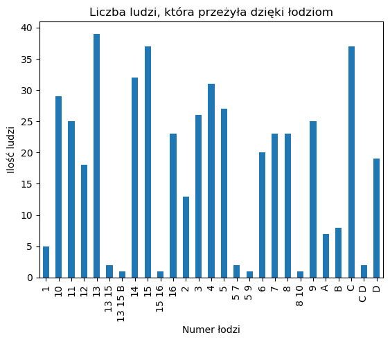

```python
# Importing necessary libraries
import pandas as pd
import matplotlib.pyplot as plt

# Adding up the number of people who survived to the boats by using groupby and sum functions
df2_grouped = df2[df2['survived'] == 1].groupby('boat')['survived'].sum()

# Plotting the data
df2_grouped.plot(kind='bar')

plt.title('Liczba ludzi, która przeżyła dzięki łodziom')
plt.xlabel('Numer łodzi')
plt.ylabel('Ilość ludzi')

plt.show()
```

## Najważniejsze obserwacje:

### * Nie wszystkie łodzie były wykorzystane w pełni – widać dużą różnicę w liczbie uratowanych między nimi.

### * Możliwe, że niektóre łodzie były mniej obciążone z powodu chaosu, braku czasu lub decyzji załogi.

# 6. Zrozumienie wartości odstających w danych

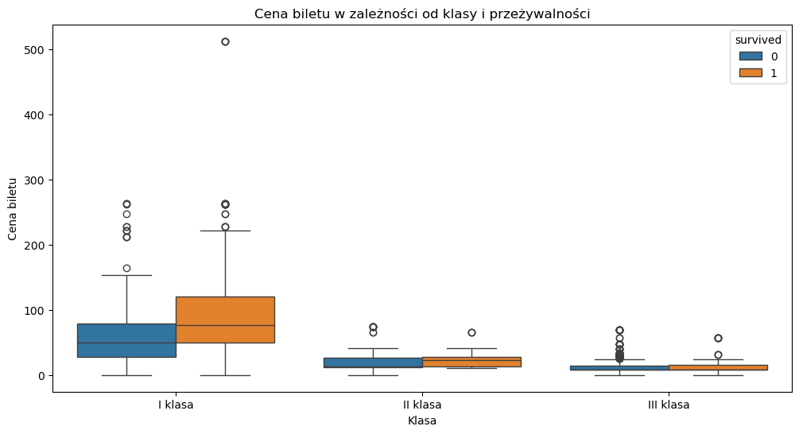

```python
plt.figure(figsize=(12, 6))
sns.boxplot(x='pclass', y='fare', hue='survived', data=df2)

# Set the labels and title
plt.xlabel('Klasa')
plt.ylabel('Cena biletu')
plt.title('Cena biletu w zależności od klasy i przeżywalności')

# Show the plot
plt.show()
```

## II klasa:

### * Różnica w cenie biletów między osobami, które przeżyły i nie przeżyły, jest mniejsza niż w przypadku I klasy.

### * Mediana ceny biletu wydaje się być nieco wyższa dla osób, które przeżyły, ale różnica jest subtelna.

## III klasa:

### * Podobnie jak w II klasie, różnica w cenie biletów między grupami jest niewielka.

### * Cena biletów w III klasie jest ogólnie najniższa.

## Wnioski:

### * Wyższa klasa (I klasa) wiązała się z wyższą ceną biletu i prawdopodobnie lepszymi warunkami podróży.

### * Osoby, które przeżyły, w I klasie, mogły mieć dostęp do lepszych zasobów lub mogły być traktowane priorytetowo podczas ewakuacji (co mogło być częściowo związane z wyższą zapłaconą ceną za bilet).

### * W niższych klasach (II i III klasa) różnica w cenie biletów między osobami, które przeżyły i nie przeżyły, jest mniej wyraźna, co może sugerować, że klasa podróży miała mniejszy wpływ na szanse przeżycia w tych klasach (lub że inne czynniki miały większe znaczenie).

## Wykres sugeruje, że cena biletu (a pośrednio klasa podróży) miała pewien wpływ na szanse przeżycia, szczególnie w I klasie. Jednakże, w II i III klasie, wpływ ten był mniej wyraźny.

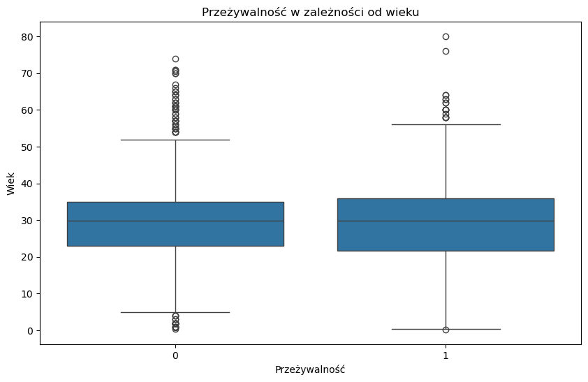

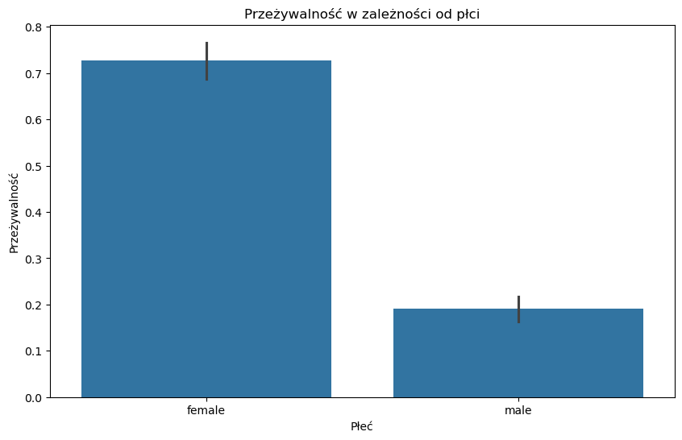

```python
# Boxplot for age based on survivability
plt.figure(figsize=(10,6))
sns.boxplot(x='survived', y='age', data=df2)
plt.title('Przeżywalność w zależności od wieku')
plt.xlabel('Przeżywalność')
plt.ylabel('Wiek')
plt.show()

# Barplot showing whether women had a higher chance of survival than men
plt.figure(figsize=(10,6))
sns.barplot(x='sex', y='survived', data=df2)
plt.title('Przeżywalność w zależności od płci')
plt.xlabel('Płeć')
plt.ylabel('Przeżywalność')
plt.show()
```

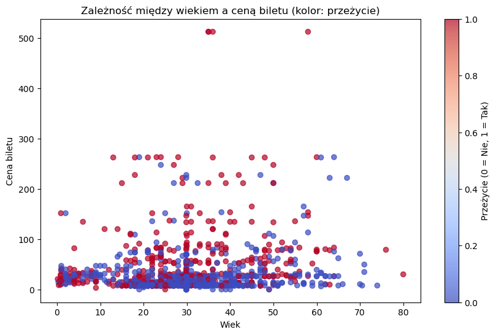

```python
import pandas as pd
import matplotlib.pyplot as plt

# Kolor punktu zależy od wartości 'survived'
plt.figure(figsize=(10, 6))
plt.scatter(df2['age'], df2['fare'], c=df2['survived'], cmap='coolwarm', alpha=0.7)

# Opis osi
plt.xlabel('Wiek')
plt.ylabel('Cena biletu')

# Tytuł wykresu
plt.title('Zależność między wiekiem a ceną biletu (kolor: przeżycie)')

# Dodajemy kolorową skalę (legendę)
cbar = plt.colorbar()
cbar.set_label('Przeżycie (0 = Nie, 1 = Tak)')

# Wyświetlamy wykres
plt.show()
```

## Kluczowe obserwacje:

### * Mediany wieku są podobne dla obu grup (ok. 30 lat).

### * Dolne i górne kwartyle są podobne – większość pasażerów miała od 20 do 40 lat.

### * Więcej wartości odstających (outliers) dla starszych osób, zwłaszcza powyżej 60 lat – oznacza to, że było niewielu bardzo starych pasażerów.

### * Kilka wartości odstających wśród najmłodszych pasażerów (około 0 lat) – możliwe, że były niemowlęta na pokładzie.

### * Rozkład dla grupy przeżywających wydaje się bardziej rozszerzony – może sugerować, że przeżyło więcej osób z różnych przedziałów wiekowych.

# Podsumowanie Analizy Danych Titanica

### Dane i Braki:

- Numer ciała (90% braków)
- Numer kabiny (80% braków)
- Numer łodzi ratunkowej (60% braków)

## Przeżywalność a Wiek i Klasa:

- Dzieci (0–10 lat) miały najwyższe szanse przeżycia (około 60%), co wynikało z zasady „kobiety i dzieci najpierw”.
- Dorosłych w średnim wieku przeżywało podobnie (35–45%), z wyjątkiem starszych, gdzie szanse były mniejsze.
- Pasażerowie I klasy, którzy płacili wyższe ceny biletów, mieli lepsze szanse na przeżycie, niż osoby z klas niższych.

## Zależności Między Zmiennymi:

- Cena biletu wykazuje dodatnią korelację z przeżyciem – wyższe ceny wiążą się z większymi szansami na przeżycie.
- Zmienne dotyczące rodziny (SibSp i Parch) są ze sobą powiązane, ale mają niewielki wpływ na przeżywalność.
- Brak związku między wiekiem, a przeżyciem sugeruje, że oprócz dzieci i bardzo starych, wiek nie był decydującym czynnikiem.